# Lecture 5: Normal and Multivariate Normal Distributions

Zhaoxia Yu

Professor, Department of Statistics

2026-04-13

```r
knitr::opts_chunk$set(echo = TRUE)
library(tidyr) #the pipe (%>%) tool is extremely useful
library(MASS)
library(corrplot)#for visualizing the corr matrix of the iris data
library(car)
```

# Outline

- The big picture: univariate vs multivariate
- Multivariate normal distribution (MVN)
- Moment generating function (MGF)
- Apply MGF to univariate and multivariate normal
  - Identify the distribution of the sample mean $\bar X$ and sample mean vector $\bar{\mathbf X}$
- Zero-Cov vs Independence. Under MVN, zero-covariance implies independence.
  - Independence between $\bar X$ and $s^2$
  - Independence between $\bar{\mathbf X}$ and $\mathbf S$

# The Big Picture

## The Big Picture: Univariate vs Multivariate

- Review: A random sample, denoted by $X_1, \cdots, X_n$, from a (univariate) normal distribution $N(\mu, \sigma^2)$
  - What are the distributions of $\bar X, s^2$? What useful statistics can be constructed?
- New material: A random sample, denoted by $\mathbf X_1, \cdots, \mathbf X_n$, from a multivariate normal distribution $N(\boldsymbol \mu, \boldsymbol \Sigma)$
  - What are the distributions of $\bar{\mathbf X}, \mathbf S$? What useful statistics can be constructed?

## The Big Picture: Univariate

- A random sample, denoted by $X_1, \cdots, X_n$, from a (univariate) normal distribution $N(\mu, \sigma^2)$
- Let $\mathbf X_{n\times 1}=(X_1, \cdots, X_n)^T$. It is random vector with a multivarite normal distribution, i.e.,
  $$\mathbf X_{n\times 1}=(X_1, \cdots, X_n)^T \sim \mathbf N(\mu\mathbf 1, \sigma^2\mathbf I)$$
1. $\bar X \sim N(\mu, \sigma^2/n)$
2. $\frac{(n-1)s^2}{\sigma^2} \sim \chi_{n-1}^2$
3. Independence between $\bar X$ and $s^2$.
4. a t-statistic is
   $$\frac{\frac{\bar X-\mu}{\sqrt{\sigma^2/n}}}{\sqrt{\frac{(n-1)s^2/\sigma^2}{n-1}}}=\frac{\sqrt{n}(\bar X-\mu)}{s}$$
   It follows the t-distribution with n-1 degrees of freedom, denoted by $t_{n-1}$.

## The Big Picture: Multivariate

- A random sample $\mathbf X_1, \cdots, \mathbf X_n$ from a multivariate normal distribution $\mathbf N(\boldsymbol \mu, \boldsymbol \Sigma)$.
- Let
  $$\mathbf X_{n\times p}=\begin{pmatrix}
  \mathbf X_1^T \\ \vdots \\\mathbf X_n^T
  \end{pmatrix}$$
  $\mathbf X$ follows a matrix normal distribution.
1. Sample mean vector follows a multivariate normal, i.e., $\bar{\mathbf X} \sim \mathbf N(\boldsymbol \mu, \boldsymbol \Sigma/n)$
2. Sample covariance matrix $(n-1)\mathbf S$ follows a Wishart distribution, i.e., $(n-1)\mathbf S \sim Wishart_p (n-1, \Sigma)$
3. Independence between $\bar {\mathbf X}$ and $S$.
4. Hoetelling’s $T^2$: $T^2 = (\bar{\mathbf X} - \boldsymbol \mu)^T\left(\frac{\mathbf S}{n}\right)^{-1} (\bar{\mathbf X} - \boldsymbol \mu)$

# MVN

## PDF of Normal and Bivariate Normal

- Univariate normal distribution:
  $$f(x) = \frac{1}{\sqrt{2\pi\sigma^2}} e^{ -\frac{(x - \mu)^2}{2\sigma^2} }$$
- Bivariate normal distribution:
  $$\begin{align*}
  f(x, y) &= \frac{1}{2\pi\sigma_1\sigma_2\sqrt{1-\rho^2}}\\ & e^{ -\frac{1}{2(1-\rho^2)} \left(\frac{(x - \mu_1)^2}{\sigma_1^2} + \frac{(y - \mu_2)^2}{\sigma_2^2} - 2\rho\frac{(x - \mu_1)(y - \mu_2)}{\sigma_1\sigma_2} \right)}
  \end{align*}$$

## PDF of MVN

The formula for a $p\ge 3$-dimensional multivariate normal distribution is much messier, so we use a compact way:

- Multivariate normal distribution:
  $$f(\mathbf{x}) = \frac{1}{\sqrt{(2\pi)^p|\boldsymbol\Sigma|}} e^{ -\frac{1}{2} (\mathbf{x} - \boldsymbol\mu)^T \boldsymbol\Sigma^{-1} (\mathbf{x} - \boldsymbol\mu)}$$

# MGF

## Tools to Characterize a Distribution

- Probability density function (PDF) or probability mass function (PMF)
- Cumulative distribution (CDF)
- Characteristic function (CF)
- Moment generating function (MGF)
- … …

## MGF of a Random Variable

- The moment generating function of random variable $X$ is defined
  $$M_X(t)=\mathbb{E}[e^{tX}]$$
- Like a PDF/PMF or CDF, a MGF uniquely determines/identifies a distribution

### Moment Generating Function: Univariate

- Where does the name of MGF come from?
  $$\begin{aligned}
  M_X(t) &= \mathbb{E}[e^{tX}] = \int_{-\infty}^{\infty} e^{tx} f(x) dx\\
  &=\int_{-\infty}^{\infty} [1 + tx + \frac{(tx)^2}{2!} + \frac{(tx)^3}{3!} + \cdots] f(x) dx\\
  &= 1+ t\mathbb{E}[X] + \frac{t^2}{2!}\mathbb{E}[X^2] + \cdots
  \end{aligned}$$
- $M^{(k)}_X(0)=E[X^K]$, where $M^{(k)}_X(t)$ is the $k$th derivative of $M_X(t)$.

## MGF of a Random Vector

- The definition can be extended to random vectors and random matrices
  - Consider a random vector $\mathbf X_{p\times 1}$. Let $t$ be a $p\times 1$ vector.

  $$M_{\mathbf X}= \mathbb E [e^{t^T\mathbf X}]$$
  - Consider a random matrix $\mathbf X_{n\times p}$. Let $t$ be a $n\times p$ matrix.

  $$M_{\mathbf X}= \mathbb E [e^{trace(t^T\mathbf X)}]$$

# MGF of Normal (univariate)

## MGF of Normal

- Recall that the MGF of a random variable X is defined as: $M_X(t) = \mathbb{E}[e^{tX}]$.
- For the normal distribution with mean $\mu$ and variance $\sigma^2$, the MGF is given by:
  $$M_X(t) = e^{\mu t + \frac{1}{2}\sigma^2t^2}$$
- The mean is $\mathbb{E}[X] = M_X'(0) = \mu$.
- The variance is
  $$\begin{aligned}
  \text{Var}(X) &= E[(X-\mu)^2] = ... =E[X^2] - (E[X])^2\\
  &= M_X''(0) - M_X'(0)^2 = \sigma^2
  \end{aligned}$$

## Examples

- Recall that $M_X(t)=exp\{\mu t + \frac{1}{2}{\sigma^2}t^2\}$ for $X\sim N(\mu, \sigma^2)$.

What is the distribution corresponding to each of the following MGFs?

1. $$M_X(t) = \exp\left(\frac{1}{2}t^2\right)$$
2. $$M_X(t) = \exp\left(2t + \frac{9}{2}t^2\right)$$
3. $$M_X(t) = \exp\left(-t + \frac{1}{8}t^2\right)$$

## Examples (continued)

1. Standard normal distribution, i.e., $\mu=0, \sigma^2=1$:
   $$M_X(t) = \exp\left(\frac{1}{2}t^2\right)$$
2. Normal distribution with mean $\mu=2$ and standard deviation $\sigma=3$:
   $$M_X(t) = \exp\left(2t + \frac{9}{2}t^2\right)$$
3. Normal distribution with mean $\mu=-1$ and standard deviation $\sigma=0.5$:
   $$M_X(t) = \exp\left(-t + \frac{1}{8}t^2\right)$$

## A Linear Function

- Let $X\sim N(\mu, \sigma^2)$. We know that $M_X(t) = \exp\left(\mu t + \frac{1}{2}\sigma^2 t^2\right)$
- Let $Y = aX + b$, where $a$ and $b$ are constants.
- We now find $M_Y(t)$:
  $$M_Y(t) = \mathbb{E}[e^{tY}] = \mathbb{E}[e^{t(aX + b)}] = e^{bt} \mathbb{E}[e^{(at)X}]$$

Since $at$ is just another constant, we can treat it as a new variable, say $s = at$. Then:
$$\begin{aligned}
M_Y(t) &= e^{bt} M_X(s) = e^{bt} \exp\{\mu s + \frac{1}{2}\sigma^2 s^2\} \\
&= \exp\{b t + a\mu t + \frac{1}{2}\sigma^2 a^2 t^2\}
= \exp\{(a\mu + b)t + \frac{1}{2}(a\sigma)^2 t^2\}
\end{aligned}$$

- $M_Y(t)$ has the form of the MGF of a normal distribution: $Y = aX + b\sim N(a\mu+b, a^2\sigma^2)$.

## Sum of Two Independent Normal Random Varaibles

- Let $X$ and $Y$ be two independent and $X\sim N(\mu_X, \sigma_X^2)$ and $Y\sim N(\mu_Y, \sigma_Y^2)$.
  $$M_X(t) = \exp\{\mu_X t + \frac{1}{2}\sigma_X^2 t^2\},
  M_Y(t) = \exp\{\mu_Y t + \frac{1}{2}\sigma_Y^2 t^2\}$$
- Let $Z = X + Y$.
  $$\begin{aligned}
  M_Z(t) &\overset{X\perp Y}= M_X(t) M_Y(t) = \exp\{\mu_X t + \frac{1}{2}\sigma_X^2 t^2\} \exp\{\mu_Y t + \frac{1}{2}\sigma_Y^2 t^2\}\\
  &=\exp\{(\mu_X+\mu_Y) t + \frac{1}{2}(\sigma_X^2+\sigma_Y^2) t^2\}
  \end{aligned}$$
  Which indicates that $Z\sim N(\mu_X+\mu_Y, \sigma_X^2+\sigma_Y^2)$

## Sample Mean from Normal

- If $X_1, \cdots, X_n \overset{iid}\sim N(\mu, \sigma^2)$.
- We have showed that $E[\bar X]=\mu$ and $Var[\bar X]=\sigma^2/n$.
- How to prove $\bar X$ follows a normal distribution?
- A compact proof:
  $$M_{\bar{X}}(t) = \prod_{i=1}^{n} M_{X_i}(\frac{t}{n})= \left(\exp\{\mu\frac{t}{n} + \frac{1}{2}\sigma^2 \frac{t^2}{n^2}\}\right)^n
  =\exp\{\mu t + \frac{1}{2}\frac{\sigma^2}{n}t^2 \}$$
  Based on the $M_{\bar X}(t)$, $\bar X\sim N(\mu, \frac{\sigma^2}{n})$.

### Sample Mean from Normal

- A proof with more details explained
  $$\begin{aligned}
  M_{\bar X}(t)&=E[e^{t\bar X}]= E[e^{\frac{t}{n} \sum_{i=1}^n X_i}]=E[e^{\frac{t}{n} X_1 + \frac{t}{n} X_2 + \cdots + \frac{t}{n} X_n}]\\
  &\overset{iid}=E[e^{\frac{t}{n} X_1}]\cdots E[e^{\frac{t}{n} X_n}]=M_{X_1}(\frac{t}{n}) \cdots M_{X_n}(\frac{t}{n})\\
  &= \exp\{\mu\frac{t}{n}+\frac{1}{2}\sigma^2 (\frac{t}{n})^2\}\cdots \exp\{\mu\frac{t}{n}+\frac{1}{2}\sigma^2 (\frac{t}{n})^2\}\\
  &= \exp\{\mu t + \frac{1}{2}\frac{\sigma^2}{n}t^2\}
  \end{aligned}$$
  Based on the $M_{\bar X}(t)$, $\bar X\sim N(\mu, \frac{\sigma^2}{n})$.

# MGF of MVN

## MGF of Multivariate Normal

- The moment generating function (MGF) of a random vector $\mathbf{X}_{p\times 1}$ is defined as: $M_{\mathbf{X}}(\mathbf{t}) = \mathbb{E}[e^{\mathbf{t}^T\mathbf{X}}]$.
- Here $t$ is a $p\times 1$ vector.
- For the multivariate normal distribution with mean vector $\boldsymbol{\mu}$ and covariance matrix $\boldsymbol{\Sigma}$, the MGF is given by:

$$M_{\mathbf{X}}(\mathbf{t}) = \exp\left( \boldsymbol{\mu}^T \mathbf{t} + \frac{1}{2} \mathbf{t}^T \boldsymbol{\Sigma} \mathbf{t} \right)$$

## Examples

1. Bivariate standard normal distribution:

$$\boldsymbol{\mu}=\begin{pmatrix}0 \\ 0\end{pmatrix}, \boldsymbol{\Sigma}=\begin{pmatrix}1 & 0 \\ 0 & 1\end{pmatrix}, M_{\mathbf{X}}(\mathbf{t}) = \exp\left(\frac{1}{2} \mathbf{t}^T \boldsymbol{\Sigma} \mathbf{t}\right)$$

2. Bivariate normal distribution with specific mean vector and covariance matrix:

$$\boldsymbol{\mu}=\begin{pmatrix}1 \\ 2\end{pmatrix},
\boldsymbol{\Sigma}=\begin{pmatrix}4 & 1 \\ 1 & 9\end{pmatrix}, M_{\mathbf{X}}(\mathbf{t}) = \exp\left(\boldsymbol{\mu}^T \mathbf{t} + \frac{1}{2} \mathbf{t}^T \boldsymbol{\Sigma} \mathbf{t}\right)$$

## A Linear Combination

- Let $\mathbf{X}_{p\times 1}\sim N(\boldsymbol \mu, \boldsymbol \Sigma)$.
- We want to show that the linear combinations $\mathbf{Y} = \mathbf{A}_{q\times p}\mathbf{X}$ also follows a multivariate normal distribution.
- The MGF of $\mathbf X$ is
  $$M_{\mathbf{X}}(\mathbf{t}) = E[e^{t^T\mathbf X}]=\exp\left(\boldsymbol{\mu}^T \mathbf{t} + \frac{1}{2} \mathbf{t}^T \boldsymbol{\Sigma} \mathbf{t}\right)$$
- To find the distribution of $Y$, we derive the MGF of $Y$.
  $$\begin{aligned}
  M_{\mathbf{Y}}(\mathbf{t}) &= E[e^{t^TAX}]=M_{\mathbf{X}}(\mathbf{A}^T \mathbf{t}) = \exp\left(\boldsymbol{\mu}^T \mathbf{A}^T \mathbf{t} + \frac{1}{2} \mathbf{t}^T \mathbf{A} \boldsymbol{\Sigma} \mathbf{A}^T \mathbf{t}\right)\\
  &=\exp\left((\mathbf{A}\boldsymbol{\mu})^T \mathbf{t} + \frac{1}{2} \mathbf{t}^T (\mathbf{A}\boldsymbol{\Sigma}\mathbf{A}^T) \mathbf{t}\right),
  \end{aligned}$$
- $M_{\mathbf{Y}}(\mathbf{t})$ has the form of the MGF of a multivariate normal distribution with mean vector $\mathbf{A}\boldsymbol{\mu}$ and covariance matrix $\mathbf{A}\boldsymbol{\Sigma}\mathbf{A}^T$.
- As a result, the linear combination
  $$\mathbf Y =A \mathbf X \sim N(A \boldsymbol \mu, \boldsymbol A \boldsymbol \Sigma A^T)$$

## The Sample Mean Vector

- Let $\mathbf X_1, \cdots \mathbf X_n$ be a random sample from $N(\boldsymbol \mu, \boldsymbol \Sigma)$.
- We have defined then the sample mean vector $\bar{\mathbf{X}}$
- We have shown that
  - $\mathbb E[\bar{\mathbf{X}}]=\boldsymbol \mu$
  - $Cov[\bar{\mathbf{X}}]=\frac{\boldsymbol \Sigma}{n}$
- Next, we will show that it follows a multivariate normal distribution.

$$\begin{aligned}
M_{\bar{\mathbf{X}}}(\mathbf{t}) &= E[e^{\mathbf{t}^T \bar {\mathbf{X}}}] = E[e^{\mathbf{t}^T(\frac{X_1}{n} + \cdots + \frac{X_1}{n})}]
= E[e^{\frac{\mathbf{t}^T}{n} X_1 + \cdots + \frac{\mathbf{t}^T}{n} X_n}]\\
&\overset{iid}= E[e^{\frac{\mathbf{t}^T}{n} X_1}] \cdots E[e^{\frac{\mathbf{t}^T}{n} X_n}]
= M_{X_1}(\frac{\mathbf{t}}{n}) \cdots M_{X_n}(\frac{\mathbf{t}}{n})\\
&= \prod_{i=1}^n M_{\mathbf{X}_i}(\frac{\mathbf{t}}{n}) = \left(\exp\left(\boldsymbol{\mu}^T \frac{\mathbf{t}}{n} + \frac{1}{2} \left(\frac{\mathbf{t}}{n}\right)^T \boldsymbol{\Sigma} \left(\frac{\mathbf{t}}{n}\right)\right)\right)^n\\
&= \exp\left(n\left(\boldsymbol{\mu}^T \frac{\mathbf{t}}{n} + \frac{1}{2n^2} \mathbf{t}^T \boldsymbol{\Sigma} \mathbf{t}\right)\right) \\
&= \exp\left(\boldsymbol{\mu}^T \mathbf{t} + \frac{1}{2} \mathbf{t}^T \frac{\boldsymbol{\Sigma}}{n} \mathbf{t}\right)
\end{aligned}$$

- $M_{\bar{\mathbf{X}}}(\mathbf{t})$ has the form of the MGF of a multivariate normal distribution with mean vector $\boldsymbol{\mu}$ and covariance matrix $\frac{\boldsymbol{\Sigma}}{n}$, i.e, $\bar{\mathbf{X}}\sim N(\boldsymbol \mu , \frac{\boldsymbol \Sigma}{n})$

# Zero-Covariance

## Independence Under Jointly Normal

- In general, zero-correlation does not guarantee independence
- Independence of normals under jointly normal: If the joint distribution of $\mathbf X_1$ (a $p\times 1$ random vector) and $\mathbf X_2$ is jointly/multivariate normal, i.e.,
  $$\begin{pmatrix}\mathbf X_1 \\ \mathbf X_2
  \end{pmatrix} \sim N(
  \begin{pmatrix}\boldsymbol \mu_1\\\boldsymbol \mu_2\end{pmatrix},
  \begin{pmatrix}\boldsymbol \Sigma_{11} & \boldsymbol \Sigma_{12}\\ \boldsymbol \Sigma_{21} & \boldsymbol \Sigma_{22}\end{pmatrix}),$$
  then $\mathbf X_1 \perp \mathbf X_2 \Leftrightarrow \boldsymbol \Sigma_{12}=0$
- Proof: omitted. A result about MGF can be used to prove independence.

## The Joint Distribution of Two Linear Functions

- Let $\mathbf{X}_{p\times 1}\sim N(\boldsymbol \mu, \boldsymbol \Sigma)$. Let $\mathbf Y=A \mathbf X$ and $\mathbf Z=B \mathbf X$.
- What is the joint distribution of $Y$ and $Z$?
- Note that
  $$\begin{pmatrix}
  \mathbf Y\\ \mathbf Z
  \end{pmatrix}=\begin{pmatrix}A \\ B\end{pmatrix}\mathbf X$$
- A linear combination of MVN random vector also follows a MVN
  $$\begin{aligned}
  \begin{pmatrix}\mathbf Y\\ \mathbf Z\end{pmatrix}
  & \sim N(\begin{pmatrix}A \\ B\end{pmatrix}\boldsymbol \mu, \begin{pmatrix}A \\ B\end{pmatrix}\boldsymbol \Sigma \begin{pmatrix}A^T & B^T\end{pmatrix})\\
  &\sim N(\begin{pmatrix}A \boldsymbol \mu \\ B\boldsymbol \mu \end{pmatrix}, \begin{pmatrix}A \boldsymbol \Sigma A^T & A \boldsymbol \Sigma B^T\\ B \boldsymbol \Sigma A^T & B \boldsymbol \Sigma B^T \end{pmatrix}\boldsymbol)
  \end{aligned}$$

We have
$$\mathbf Y \perp \mathbf Z \Leftrightarrow A\Sigma B^T=0$$

# A Simulation Question

- Suppose we have a random sample from a normal distribution.
- How to use a simulation to show that sample mean and sample variance are uncorrelated (in fact they are also independent)?

```r
X=matrix(rnorm(1000*100, 0, 1), 1000, 100)
means=rowMeans(X)
vars=apply(X, 1, var)
plot(means, vars)
```

## A Simulation Question

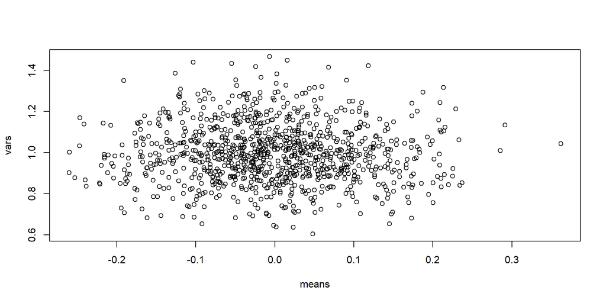

# Indepdence between sample mean (vector) and sample variance (covariance matrix)

## Univariate: Sample Mean and Sample Variance

### The Independence Between Sample Mean and Sample Variance

- For a random sample from a normal distribution, the sample mean and sample variance are independent.
- Let $\mathbf X =(X_1, X_2, ..., X_n)^T$ be a random sample from a normal distribution with mean $\mu$ and variance $\sigma^2$.
- The sample mean and sample variance are defined as:
  - Sample mean: $\bar{X} = \frac{1}{n} \sum_{i=1}^{n} X_i$
  - Sample variance: $s^2 = \frac{1}{n-1} \sum_{i=1}^{n} (X_i - \bar{X})^2$
- We want to show that $\bar{X}$ and $s^2$ are independent.

### Proof

- We first rewrite the sample mean:
  $$\bar{X} = \frac{1}{n} \sum_{i=1}^{n} X_i =\frac{1}{n}\mathbf 1^T \mathbf X$$
- We have shown that $s^2 = \frac{1}{n-1} \sum_{i=1}^{n} (X_i - \bar{X})^2=\frac{1}{n-1}X^T\mathbb CX$, where $\mathbb C=\mathbf I - \frac{1}{n}\mathbf 1 \mathbf 1^T$. In addition, it is easy to verify that $\mathbb C=\mathbb C^T, \mathbb C^2=\mathbb C$.

Thus, the distribution of $s^2$ can be rewritten to
$$s^2=\frac{1}{n-1} (\mathbb C\mathbf X)^T (\mathbb C\mathbf X),$$
which indicates that the distribution $s^2$ is determined by the distribution of $\mathbb C X$.

### Proof (continued)

- Clearly $\bar {\mathbf X}$ and $\mathbb C \mathbf X$ are linear combinations of $\mathbf X$, which follows a multivariate normal with covariance $\boldsymbol\Sigma= \mathbf I$. Thus,
  $$cov(\bar {\mathbf X}, \mathbb C \mathbf X) = \frac{1}{n}\mathbf 1^T \Sigma \mathbb C= \frac{1}{n}\mathbf 1^T \mathbb C=0$$
  Please verify that last step.

By Theorem on “Independence of Normals Under Jointly Normal”, we can conclude the $\bar {\mathbf X}$ and $s^2$ are independent.

## Multivariate: sample mean vector and sample covariance matrix

### The Independence

- How to prove that the sample mean vector and the sample covariance matrix are independent
- Messier way: vectorize the $n\times p$ matrix $\mathbf X$ to a $(np)\times 1$ vector and then apply the condition for independent linear combinations under MVN
- Neater way: use properties of Matrix Normal Distribution

### Sample Mean Vector and Sample Covariance Matrix

- If we have a random sample from MVN, we will show that $\bar{\mathbf X}$ and $S$ are independent
- Proof outline
1. Vectorize $\mathbf X_{n\times p}$ to a vector $\tilde {\mathbf X}_{(np)\times 1}$, which follows a MVN
2. Show that the distribution of $\bar{\mathbf X}$ is determined by a linear function of $\tilde {\mathbf X}_{(np)\times 1}$
3. Show that the distribution of $S$ is determined by a linear function of $\tilde {\mathbf X}_{(np)\times 1}$
4. Find the covariance of the two linear functions
5. Conclude that the two linear functions are independent, which indicates that the sample mean vector and the sample covariance matrix are independent

### Step 1a: Vectorize

- We vectorize $\mathbf X_{n\times p}$ such that
  - the first $n$ random variables are for the first feature
  - the last $n$ random variables are for the last feature

$$\tilde {\mathbf X}_{(np)\times 1}=
\begin{pmatrix}
\mathbf X_{(1)}\\ \vdots \\ \mathbf X_{(p)} \end{pmatrix}$$

- What is the distribution of $\mathbf X_{(1)}$?
- The distribution of $\mathbf X_{(1)}$?
  $$\begin{aligned}
  \mathbf X_{(1)} &\sim N(
  \begin{pmatrix}
  \mu_1 \\ \vdots \\ \mu_1
  \end{pmatrix},
  \begin{pmatrix}
  \sigma_{11}^2 & 0 & \cdots& 0\\
  0 & \sigma_{11}^2 & \cdots & 0\\
  \vdots & \vdots & \ddots & \vdots\\
  0 & 0 & \cdots & \sigma_{11}^2
  \end{pmatrix}
  )\\
  &\sim N(\mu_1 \mathbf 1_n, \sigma_{11}^2 \mathbf I)
  \end{aligned}$$

### Step 1b: The distribution of $\mathbf x_{n\times p}$

$$\begin{aligned}
\tilde {\mathbf X}_{(np)\times 1} &=
\begin{pmatrix}
\mathbf X_{(1)}\\ \vdots \\ \mathbf X_{(p)} \end{pmatrix}
\sim N(\boldsymbol \mu \otimes\mathbf 1_n,
\boldsymbol \Sigma \otimes \mathbf I_n)\\
&\sim
N (
\begin{pmatrix}\mu_1 \mathbf 1_n \\ \vdots \\\mu_p \mathbf 1_n\end{pmatrix},
\begin{pmatrix}
\sigma_{11}\mathbf I_n & \cdots & \sigma_{1p}\mathbf I_n\\
\cdots & \cdots & \cdots \\
\sigma_{p1}\mathbf I_n & \cdots & \sigma_{pp}\mathbf I_n
\end{pmatrix})
\end{aligned}$$

### Step 2: The sample mean vector

- The sample mean vector can be written as linear functions of $\tilde {\mathbf X}$:
  $$\bar{\mathbf X}=\frac{1}{n} \begin{pmatrix} \mathbf 1_n^T & \mathbf 0_n^T & \cdots &\mathbf 0_n^T \\
  \mathbf 0_n^T & \mathbf 1_n^T & \cdots &\mathbf 0_n^T \\
  \cdots & \cdots & \cdots & \cdots \\
  \mathbf 0_n^T & \mathbf 0_n^T & \cdots &\mathbf 1_n^T
  \end{pmatrix} \tilde {\mathbf X}$$

### Step 3: The sample covariance matrix

- Recall that we have shown the following result
  $$S=\frac{1}{n-1} \mathbf X^T \mathbb C \mathbf X= \frac{1}{n-1} (\mathbb C \mathbf X)^T \mathbb C \mathbf X$$
- So we only need to focus on $\mathbb C \mathbf X$, the centered random matrix.
- The vectorized version of the centered random matrix is
  $$vec(\mathbb C \mathbf X) =
  \begin{pmatrix}
  \mathbb C & \mathbf 0 & \cdots & \mathbf 0\\
  \mathbf 0 & \mathbb C & \cdots & \mathbf 0\\
  \cdots & \cdots & \cdots & \cdots\\
  \mathbf 0 & \mathbf 0 & \cdots & \mathbb C
  \end{pmatrix}_{(np)\times (np)} \tilde {\mathbf X}$$

### Step 4: The covariance of the two linear functions

So we have the following results

$$\begin{aligned}
\tilde {\mathbf X}_{(np)\times 1}
& \sim N(\boldsymbol \mu \otimes\mathbf 1_n,
\boldsymbol \Sigma \otimes \mathbf I_n)\\
& \sim
N (
\begin{pmatrix}\mu_1 \mathbf 1_n \\ \vdots \\\mu_p \mathbf 1_n\end{pmatrix},
\begin{pmatrix}
\sigma_{11}\mathbf I_n & \cdots & \sigma_{1p}\mathbf I_n\\
\cdots & \cdots & \cdots \\
\sigma_{p1}\mathbf I_n & \cdots & \sigma_{pp}\mathbf I_n
\end{pmatrix})
\end{aligned}$$

The distribution of $\bar{\mathbf X}$ and $S$ depend on

$$\begin{aligned}
\bar{\mathbf X}&=\frac{1}{n} \begin{pmatrix}
\mathbf 1_n^T & \mathbf 0_n^T & \cdots &\mathbf 0_n^T \\
\mathbf 0_n^T & \mathbf 1_n^T & \cdots &\mathbf 0_n^T \\
\cdots & \cdots & \cdots & \cdots \\
\mathbf 0_n^T & \mathbf 0_n^T & \cdots &\mathbf 1_n^T
\end{pmatrix} \tilde {\mathbf X}, \\
vec(\mathbb C \mathbf X) &=
\begin{pmatrix}
\mathbb C & \mathbf 0 & \cdots & \mathbf 0\\
\mathbf 0 & \mathbb C & \cdots & \mathbf 0\\
\cdots & \cdots & \cdots & \cdots\\
\mathbf 0 & \mathbf 0 & \cdots & \mathbb C
\end{pmatrix} \tilde {\mathbf X}
\end{aligned}$$

- Let $\tilde {\boldsymbol \Sigma}$ denote the covariance matrix of $\tilde {\mathbf x}$
- Let $\mathbb A$ denote the matrix such that $\bar{\mathbf X}=\mathbb A \tilde {\mathbf x}$
- Let $\mathbb B$ denote the matrix such that $vec(\mathbb C\mathbf X)=\mathbb B \tilde {\mathbf X}$
- It can be verified that $\mathbb A \tilde {\boldsymbol \Sigma} \mathbb B^T=\mathbf 0$.

### Step 5: The independnece of the two linear functions

- Both $\bar{\mathbf X}$ and $vec(\mathbb C\mathbf X)$ are linear function of the same MVN-distributed random vector $\tilde {\mathbf X}$
- Their covariance matrix is zero, which indicates that they are independent by Theorem on “Independence of Normals Under Jointly Normal”.
- The sample covariance matrix only depends on the centered data,$vec(\mathbb C\mathbf X)$ (the vector form) up to a constant
- Therefor, if we have a random sample from a , the sample mean vector and the sample covariance matrix are independent
- The proof is lengthy. It can be more compact if we introduce matrix normal distribution.